# ggplot

Nai Hsuan Shao (35980135)

2018-03-19

## Working with data in R

### Exercise 1

We have another data table we will be using in up-coming DS Fridays, Saanich.OTU.txt. Import this data as a named object with the correct parameters in R.

```r
OTU = read.table(file="Saanich.OTU.txt", header=TRUE, row.names=1, sep="\t")
```

### Exercise 2

Using dplyr, find at what depth(s) methane (CH4) is above 100 nM while temperature is below 10 °C. Print out a table showing only the depth, methane, and temperature data.

```r
metadata %>%
  filter(CH4_nM >= 100) %>%
  filter(Temperature_C <= 10) %>%
  select(Depth_m, CH4_nM, Temperature_C)
```

```
##   Depth_m  CH4_nM Temperature_C
## 1     185 310.068         9.091
## 2     200 774.034         9.117
```

### Exercise 3

Convert all variables that are in nM to μM. Output a table showing only the original nM and converted μM variables

```r
metadata %>%
  select(matches("nM")) -> nM_table

nM_table %>%
  mutate(N2O_um = N2O_nM/1000) %>%
  mutate(Std_N2O_um = Std_N2O_nM/1000) %>%
  mutate(CH4_um = CH4_nM/1000) %>%
  mutate(Std_CH4_um = Std_CH4_nM/1000)
```

```
##    N2O_nM Std_N2O_nM   CH4_nM Std_CH4_nM   N2O_um Std_N2O_um   CH4_um
## 1   0.849      0.114 1030.478      3.070 0.000849   0.000114 1.030478
## 2  13.199      0.000   29.012      0.000 0.013199   0.000000 0.029012
## 3  12.829      1.509   37.146      2.695 0.012829   0.001509 0.037146
## 4  12.306      0.524   36.501      3.521 0.012306   0.000524 0.036501
## 5  13.896      1.417   24.013      0.435 0.013896   0.001417 0.024013
## 6  12.959      0.955    7.376      0.029 0.012959   0.000955 0.007376
## 7  15.551      1.417    4.190      0.159 0.015551   0.001417 0.004190
## 8  18.682      1.628    3.991      0.759 0.018682   0.001628 0.003991
## 9  18.087      1.275    3.231      0.392 0.018087   0.001275 0.003231
## 10 15.843      1.953    3.633      0.127 0.015843   0.001953 0.003633
## 11 16.304      1.085    3.463      0.519 0.016304   0.001085 0.003463
## 12 12.909      2.577    4.815      0.658 0.012909   0.002577 0.004815
## 13 11.815      0.000    8.323      0.000 0.011815   0.000000 0.008323
## 14  6.310      0.732   23.831      2.291 0.006310   0.000732 0.023831
```

[output cut: 19 more lines]

## Plotting data in R

### Exercise 1

Plot another nutrient of your choice against depth. Change the points to be purple triangles.

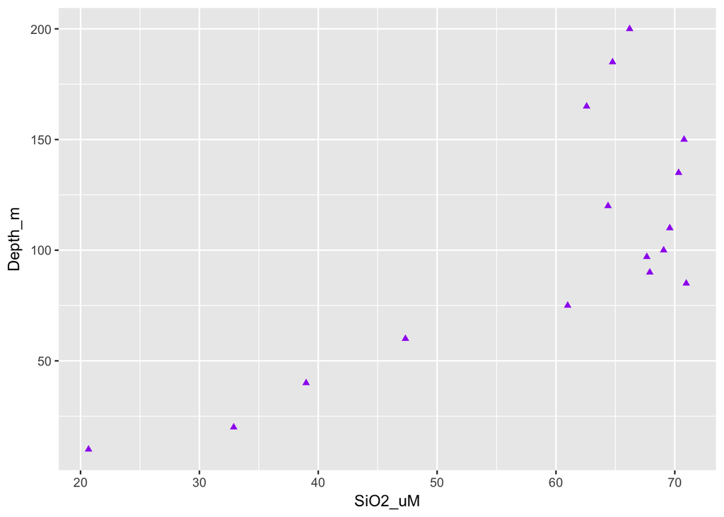

```r
ggplot(metadata, aes(x=SiO2_uM, y=Depth_m))+
  geom_point(shape=17,color="purple")
```

###Exercise 2 Using dplyr, convert the temperature variable from Celsius to Fahrenheit. Then create a dot plot of temperature in Fahrenheit against depth

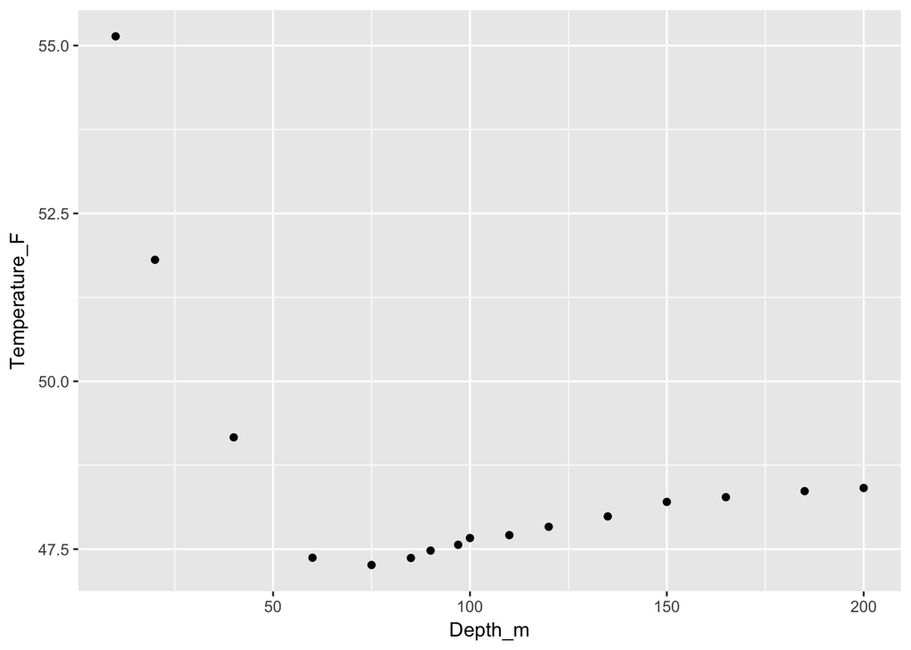

```r
metadata %>%
  mutate(Temperature_F = Temperature_C*9/5+32) %>%
  ggplot() + geom_point(aes(x=Depth_m, y=Temperature_F))
```

###Exercise 3 Create a bar plot at a different taxonomic level with more descriptive x- and y-axis labels as well as a title. Use the ggplot cheatsheet to learn the guides needed to change these labels.

```r
physeq
```

```
## phyloseq-class experiment-level object
## otu_table()   OTU Table:         [ 4368 taxa and 7 samples ]
## sample_data() Sample Data:       [ 7 samples by 22 sample variables ]
## tax_table()   Taxonomy Table:    [ 4368 taxa by 7 taxonomic ranks ]
## phy_tree()    Phylogenetic Tree: [ 4368 tips and 4366 internal nodes ]
```

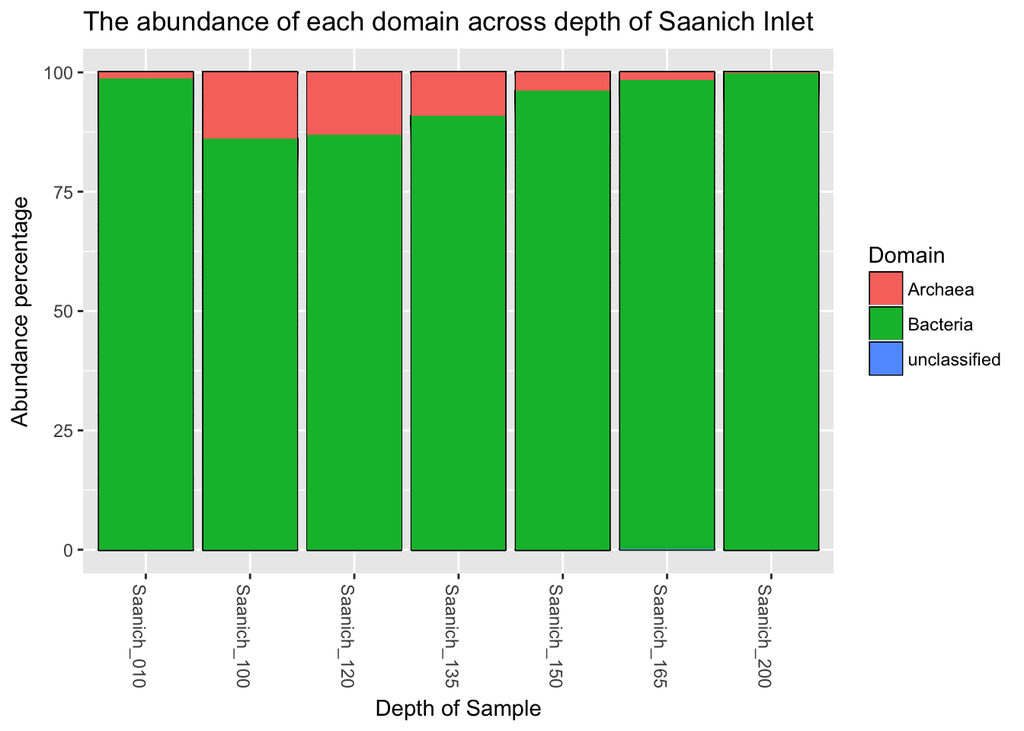

```r
physeq_percent = transform_sample_counts(physeq, function(x) 100 * x/sum(x))

plot_bar(physeq_percent, fill="Domain") +
  geom_bar(aes(fill=Domain), stat="identity")+
  labs(x="Depth of Sample", y="Abundance percentage", title="The abundance of each domain across depth of Saanich Inlet")
```

###Exercise 4 Using ggplot, create a faceted figure showing nutrient concentrations in uM for O2, PO4, SiO2, NO3, NH4, and NO2 by depth. For this, you can use either the metadata table or the phyloseq object.

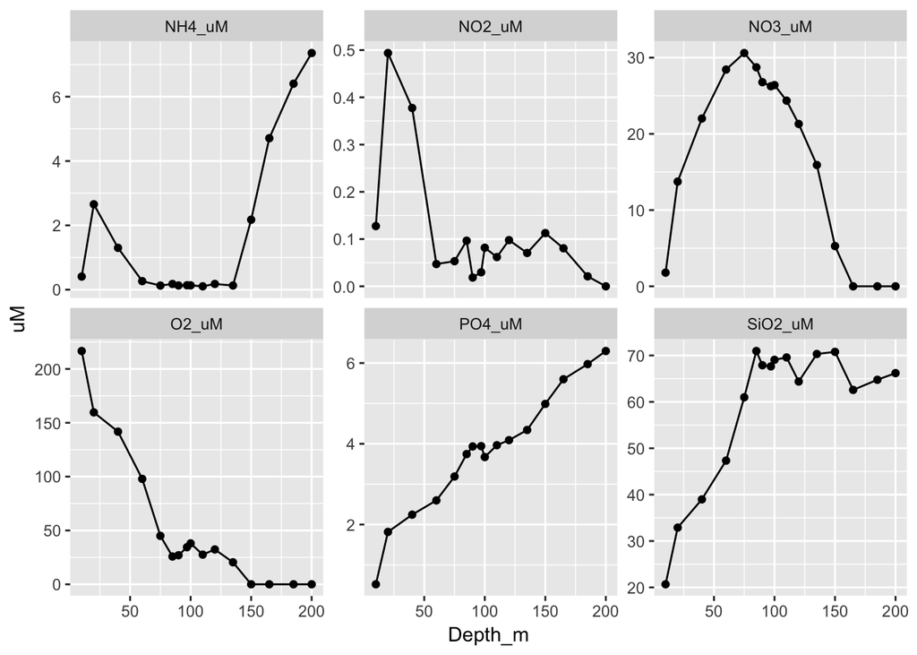

```r
ggplot(metadata %>%
  select(Depth_m, O2_uM, PO4_uM, SiO2_uM, NO3_uM, NH4_uM, NO2_uM) %>%
  gather(key = Nutrient, value = uM, -Depth_m), aes(x=Depth_m, y=uM))+
  geom_point(aes(x=Depth_m, y=uM), stat="identity") +
  geom_line(aes(x=Depth_m, y=uM)) +
  theme(legend.position="none")+
  facet_wrap(~Nutrient, scales="free_y")+
  theme(legend.position="none")
```